# Détection de faux billets avec R

Abdelmajid EL HOU - data analyst (*[Mon ePortfolio](https://abdelmajidlh.github.io/ePortfolio/)*)

02/02/2022

# 1 Introduction

## 1.1 Contexte du projet

L’Organisation nationale de lutte contre le faux-monnayage, ou ONCFM, est une organisation publique ayant pour objectif de mettre en place des méthodes d’identification des contrefaçons des billets en euros. Dans le cadre de cette lutte, l’ONCFM souhaite mettre en place un algorithme qui soit capable de différencier automatiquement les vrais des faux billets.

## 1.2 Objectif

Lorsqu’un billet arrive, une machine consigne l’ensemble de ses caractéristiques géométriques. Au travers des années de lutte, l’ONCFM a observé des différences de dimensions entre les vrais et les faux billets. Ces différences sont difficilement notables à l’œil nu, mais une machine devrait sans problème arriver à les différencier. Ainsi, il faudrait construire un **algorithme** qui, à partir des caractéristiques géométriques d’un billet, serait capable de définir si ce dernier est un vrai ou un faux billet.

## 1.3 Cométences à mobiliser

Les compétences à acquérir dans ce projet:

- Réaliser une analyse prédictive
- Opérer des classifications automatiques pour partitionner les données
- Réaliser une régression logistique
- Réaliser une régression linéaire

# 2 Importation et nettoyage des données

```r
# Définir le dossier de travail
setwd("C:/Users/abdel/Desktop/Projet 10/P10_Abdelmajid_EL_HOU")
```

## 2.1 Packages et fonctions

```r
suppressMessages(require(tidyverse)) # pour la manipulation et la visualisation des données
suppressMessages(require(DataExplorer))
suppressMessages(require(e1071))
suppressMessages(require(caret)) # regression logistique
suppressMessages(require(caTools))
#suppressMessages(require(InformationValue))
suppressMessages(require(missMDA)) # offre des fonctions R facilitant l'imputation des données manquantes
suppressMessages(require(ggplot2))
suppressMessages(require(corrplot))
suppressMessages(require(purrr))
suppressMessages(require(hrbrthemes))
suppressMessages(require(visdat))
suppressMessages(require(knitr))

# tester la normalité & variances
suppressMessages(require(ggpubr)) # pour créer facilement des graphiques prêts à la publication
suppressMessages(require(rstatix)) # offre des fonctions R facilitant les analyses statistiques
#suppressMessages(require(car)) # tests statistiques

#clustering
suppressMessages(require(FactoMineR))
suppressMessages(require(FactoInvestigate))
suppressMessages(require(factoextra))
suppressMessages(require(cluster))
suppressMessages(require(gridExtra))
suppressMessages(require(DataExplorer))
```

## 2.2 Préparation des données

```r
# importer le fichier csv
df =  read.csv2("data/billets.csv", sep = ";") # encoding = "UTF-8"
```

```r
# Convertir les chaînes de caractères en numeric dans notre jeu de données
i = c(2,3,4,5,6,7)

df[ , i] <- apply(df[ , i], 2,
                    function(x) as.numeric(as.character(x)))
```

```r
# Afficher les premières lignes
kable(df[1:5,], caption = "Head dataframe")
```

Head dataframe

| is_genuine | diagonal | height_left | height_right | margin_low | margin_up | length |
| --- | --- | --- | --- | --- | --- | --- |
| True | 171.81 | 104.86 | 104.95 | 4.52 | 2.89 | 112.83 |
| True | 171.46 | 103.36 | 103.66 | 3.77 | 2.99 | 113.09 |
| True | 172.69 | 104.48 | 103.50 | 4.40 | 2.94 | 113.16 |
| True | 171.36 | 103.91 | 103.94 | 3.62 | 3.01 | 113.51 |
| True | 171.73 | 104.28 | 103.46 | 4.04 | 3.48 | 112.54 |

```r
# Taille de mon jeu de données
dim(df)
```

```
## [1] 1500    7
```

```r
# nombre de faux/vrai billets
table(df$is_genuine)
```

```
##
## False  True
##   500  1000
```

- Le jeu de données est composé de 1500 observations (1000 vrais billets et 500 faux) et de 7 variables (1 catégorielle et 6 numériques).

```r
# Ajouter une colonne ID
df <- tibble::rowid_to_column(df, "ID")
```

## 2.3 Gérer les valeurs manquantes

### 2.3.1 Visualisation des valeurs manquantes

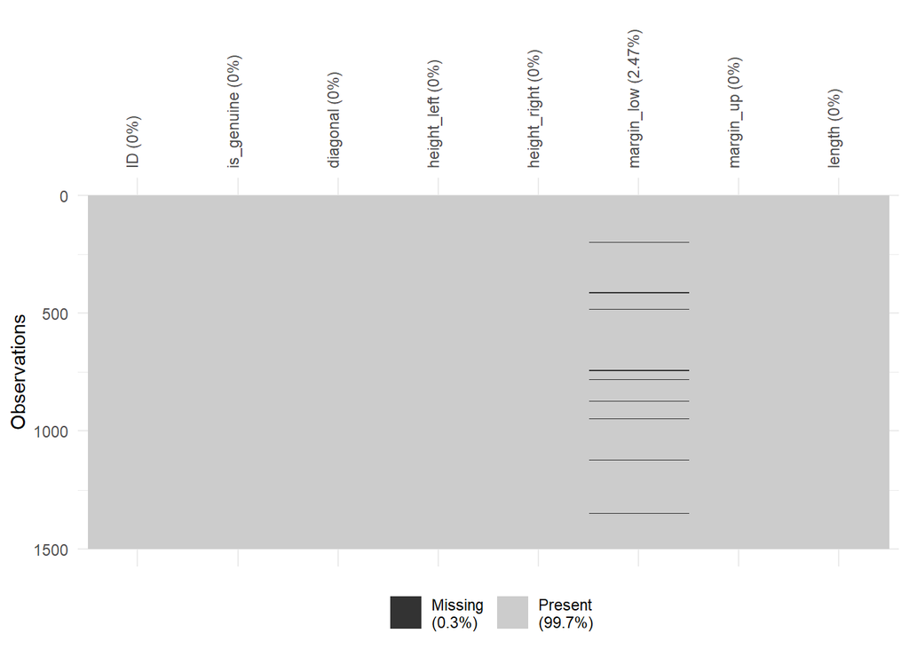

```r
vis_miss(df) + theme(axis.text.x =  element_text(angle = 90))
```

- Nous avons au total 37 valeurs manquantes (0.3 % du total).
- Ces valeurs manquantes sont situées au niveau de la colonne margin_low (2.47 %).

```r
# Créer un nouveau jeu de données sans valeurs manquantes
df2 = df %>% filter(!is.na(margin_low))
```

### 2.3.2 Imputation des valeurs manquantes par regression linéaire

La régression linéaire multiple est une extension de la régression linéaire simple utilisée pour prédire une variable de résultat (y) sur la base de multiples variables prédictives distinctes (x).

Par exemple, avec trois variables prédictives (*x*), la prédiction de *y* est exprimée par l’équation suivante :

$$y = b0 + b1*x1 + b2*x2 + b3*x3$$
* Les valeurs *b* sont appelées les poids de régression (ou coefficients bêta). * Elles mesurent l’association entre la variable prédictive et le résultat. * *b_j* peut être interprété comme l’effet moyen sur *y* d’une augmentation d’une unité de *x_j*, en maintenant tous les autres prédicteurs fixes.

#### 2.3.2.1 Construire le modèle

Nous voulons construire un modèle d’estimation de la variable *margin_low* basé sur les autres variables numériques, comme suit :
$$margin\_low = b0 + b1*diagonal + b2*height\_left + b3*height\_right + b4*margin\_up + b5*length$$

```r
# Calculer les coefficients du modèle
model <- lm(margin_low ~ diagonal + height_left + height_right + margin_up + length, data = df2)
summary(model)
```

```
##
## Call:
## lm(formula = margin_low ~ diagonal + height_left + height_right +
##     margin_up + length, data = df2)
##
## Residuals:
##      Min       1Q   Median       3Q      Max
## -1.47234 -0.31707 -0.04168  0.27353  1.97084
##
## Coefficients:
##              Estimate Std. Error t value Pr(>|t|)
## (Intercept)  22.99484    9.65555   2.382  0.01737 *
## diagonal     -0.11106    0.04144  -2.680  0.00744 **
## height_left   0.18412    0.04477   4.113 4.13e-05 ***
## height_right  0.25714    0.04301   5.978 2.84e-09 ***
## margin_up     0.25619    0.06437   3.980 7.23e-05 ***
## length       -0.40910    0.01808 -22.627  < 2e-16 ***
## ---
## Signif. codes:  0 '***' 0.001 '**' 0.01 '*' 0.05 '.' 0.1 ' ' 1
##
## Residual standard error: 0.4807 on 1457 degrees of freedom
## Multiple R-squared:  0.4773, Adjusted R-squared:  0.4755
## F-statistic: 266.1 on 5 and 1457 DF,  p-value: < 2.2e-16
```

#### 2.3.2.2 Interprétation

- La valeur *p* de la statistique F est < 2.2e-16, ce qui est hautement significatif. Cela signifie qu’au moins une des variables prédictives est liée de manière significative à la variable de résultat.
- Pour voir quelles variables prédictives sont significatives, on peux examiner le tableau des coefficients, qui montre l’estimation des coefficients bêta de la régression et les valeurs t-statistiques *p* associées :

```r
summary(model)$coefficient
```

```
##                Estimate Std. Error    t value     Pr(>|t|)
## (Intercept)  22.9948427 9.65555437   2.381514 1.736939e-02
## diagonal     -0.1110598 0.04143929  -2.680060 7.443859e-03
## height_left   0.1841224 0.04477112   4.112527 4.132146e-05
## height_right  0.2571380 0.04301419   5.977983 2.836546e-09
## margin_up     0.2561879 0.06437032   3.979907 7.233463e-05
## length       -0.4091029 0.01808053 -22.626708 2.183858e-97
```

Pour un prédicteur donné, la statistique $t$ évalue s’il existe ou non une *association significative* entre le *prédicteur* et la variable de *résultat*, c’est-à-dire si le coefficient *bêta* du prédicteur est significativement différent de zéro.

- On constate que les 5 variables géometriques sont significativement associées à la variation de la variable $margin\_low$.
- Pour une variable prédictive donnée, le coefficient (*b*) peut être interprété comme l’effet moyen sur $y$ d’une augmentation d’une unité de la variable prédictive, toutes les autres variables prédictives étant fixes.
- Enfin, l’équation de notre modèle peut être écrite comme suit :
  $$margin\_low = 22.99 - 0.11*diagonal + 0.18*height\_left + 0.26*height\_right + 0.26*margin\_up - 0.41*length$$

L’intervalle de confiance du coefficient du modèle :

```r
confint(model)
```

```
##                    2.5 %      97.5 %
## (Intercept)   4.05456999 41.93511544
## diagonal     -0.19234683 -0.02977273
## height_left   0.09629969  0.27194515
## height_right  0.17276170  0.34151440
## margin_up     0.12991949  0.38245631
## length       -0.44456959 -0.37363628
```

#### 2.3.2.3 Évaluation de la précision du modèle

La qualité globale du modèle peut être évaluée en examinant le R-carré ($R^2$) et l’erreur standard résiduelle (*RSE*).

##### 2.3.2.3.1 R-carré

- Dans la régression linéaire multiple, le $R^2$ représente le **coefficient de corrélation** entre les valeurs observées de la variable de résultat ($y$) et les valeurs ajustées (c’est-à-dire prédites) de $y$. Pour cette raison, la valeur de $R$ sera toujours positive et sera comprise entre 0 et 1.
- $R^2$ représente la proportion de la variance, dans la variable de résultat $y$, qui peut être prédite en connaissant la valeur des variables $x$. Une valeur $R^2$ proche de 1 indique que le modèle explique une grande partie de la variance de la variable de résultat.

Un problème avec le $R^2$, est qu’il augmentera toujours lorsque plus de variables sont ajoutées au modèle, même si ces variables ne sont que faiblement associées à la réponse (James et al. 2014). Une solution consiste à ajuster le $R^2$ en tenant compte du nombre de variables prédictives.

L’ajustement de la valeur du “R carré ajusté” dans la sortie du résumé est une correction pour le nombre de variables *x* incluses dans le modèle de prédiction.

*Dans notre exemple, avec les 5 variables prédictives, le $R^2$ ajusté = 0,475, ce qui signifie que 47.5% de la variance de margin_low peut être prédite par les 5 variables.*

##### 2.3.2.3.2 Residual Standard Error (RSE), ou sigma:

L’estimation $RSE$ donne une mesure de l’erreur de prédiction. Plus le RSE est faible, plus le modèle est précis (sur les données en question).

Le taux d’erreur peut être estimé en divisant $RSE$ par la variable de résultat moyenne :

```r
sigma(model)/mean(df2$margin_low)
```

```
## [1] 0.1071629
```

- la valeur est proche de 0, donc *notre modèle semble être précis à 90 %*.

##### 2.3.2.3.3 Détection de la multicollinéarité entre variables

- Dans la régression multiple, deux variables prédictives ou plus peuvent être corrélées entre elles. Cette situation est appelée **colinéarité**.
- Il existe une situation extrême, appelée **multicollinéarité**, où la colinéarité existe entre trois variables ou plus, même si aucune paire de variables ne présente une corrélation particulièrement élevée. Cela signifie qu’il existe une **redondance entre les variables prédictives**.
- En présence de multicollinéarité, la solution du modèle de régression devient instable.
- Pour un prédicteur donné ($p$), la multicollinéarité peut être évaluée en calculant un score appelé **facteur d’inflation de la variance** (ou *VIF*), qui mesure **à quel point la variance d’un coefficient de régression est gonflée en raison de la multicollinéarité du modèle**.

Face à la multicollinéarité, **les variables concernées doivent être supprimées**, car la présence de la multicollinéarité implique que l’information que cette variable fournit sur la réponse est **redondante** en présence des autres variables (James et al. 2014,P. Bruce et Bruce (2017)). [Source](http://www.sthda.com/english/articles/39-regression-model-diagnostics/160-multicollinearity-essentials-and-vif-in-r/)

```r
# Detecter la multicolinéarité
car::vif(model)
```

```
##     diagonal  height_left height_right    margin_up       length
##     1.013613     1.138261     1.230115     1.404404     1.576950
```

- Les scores des 5 variables sont proche de 1, donc aucune multi-colinéarité n’est présente entre les variables.

#### 2.3.2.4 Remplacer les valeurs manquantes dans le fichier original en appliquant le modèle

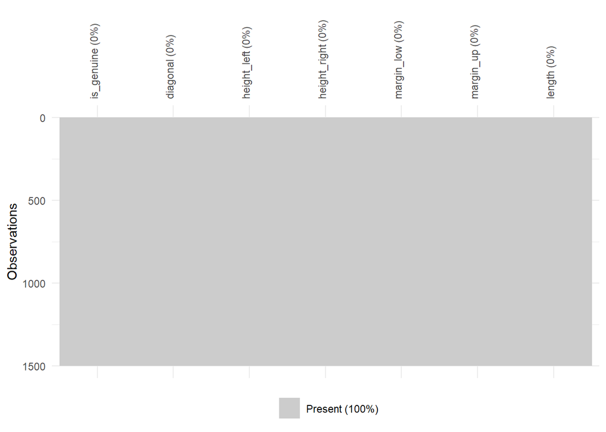

```r
# Utiliser le modèle pour prédire la valeur de margin_low
df3 <- df %>%
  mutate(pred = predict(model, .)) %>%
  mutate(margin_low = ifelse(is.na(margin_low), pred, margin_low))

# Voir le résultat
df3 = df3 %>% select(ID, is_genuine, diagonal, height_left, height_right, margin_low, margin_up, length) %>% as.data.frame()

vis_miss(df3[,-1]) + theme(axis.text.x =  element_text(angle = 90))
```

- Les valeurs manquantes sont bien imputées..

# 3 Analyse exploratoire des données

## 3.1 Description des données

```r
# Calcul de la moyenne par catégorie de billet
for (col in 3:ncol(df3)) {
    print(paste0("------",colnames(df3)[col], "------"),collapse ="\t")
    moy = tapply(df3[,col], df3[,2], mean)
    print(moy)
}
```

```
## [1] "------diagonal------"
##    False     True
## 171.9012 171.9871
## [1] "------height_left------"
##    False     True
## 104.1903 103.9491
## [1] "------height_right------"
##    False     True
## 104.1436 103.8087
## [1] "------margin_low------"
##    False     True
## 5.214079 4.118174
## [1] "------margin_up------"
##   False    True
## 3.35016 3.05213
## [1] "------length------"
##    False     True
## 111.6306 113.2024
```

*Un portrait-robot d’un vrai billet :*

- Diagonale : 171.98 mm.
- Hauteur mesurée à gauche : 103.94 mm
- Hauteur mesurée à droite : 103.80 mm,
- Marge entre le bord inférieur et le bord de l’image : 4.11 mm
- Marge entre le bord supérieur et le bord de l’image :3.05 mm,
- Longueur : 113.20 mm,

## 3.2 Distribution des variables

### 3.2.1 Test de Normalité

Les tests de corrélation, de régression, les tests t et l’analyse de variance, supposent que les données suivent une distribution normale. Ces tests sont appelés tests paramétriques, car leur validité dépend de la distribution des données.

Vérifier la normalité des données dans R par inspection visuelle (graphique QQ plot et distributions de densité) et par des tests de statistiques (test de Shapiro-Wilk) [source](https://www.datanovia.com/en/fr/lessons/test-de-normalite-dans-r/)

#### 3.2.1.1 Visuellement

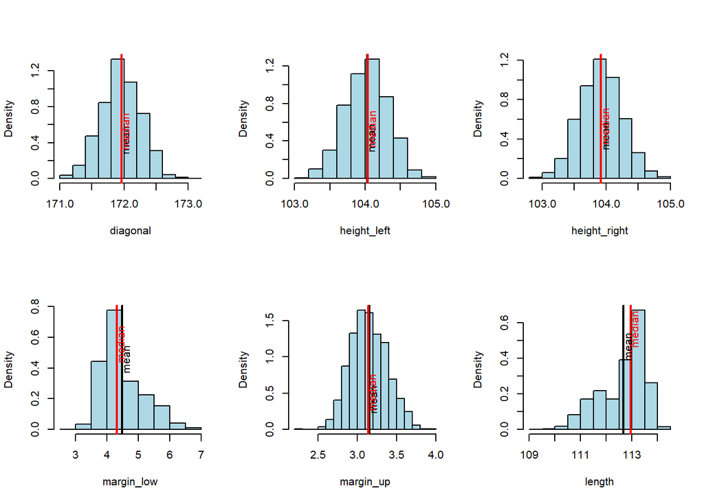

```r
#plot_histogram(data =df3, ggtheme = theme_classic())
par(mfrow=c(2,3))
for (col in 3:ncol(df3)) {
    mean <- mean(df3[,col])
    med  <- median(df3[,col])
    hist(df3[,col], col="lightblue", main = "", freq=FALSE, xlab = colnames(df3)[col])
    abline(v = mean, col = 'black', lwd = 2)
    abline(v = med, col = 'red', lwd = 2)
    text(mean, 0.5, "mean", col="black", srt=90,pos=1)
    text(med, 0.6, "median", col="red", srt=90,pos=1)
}
```

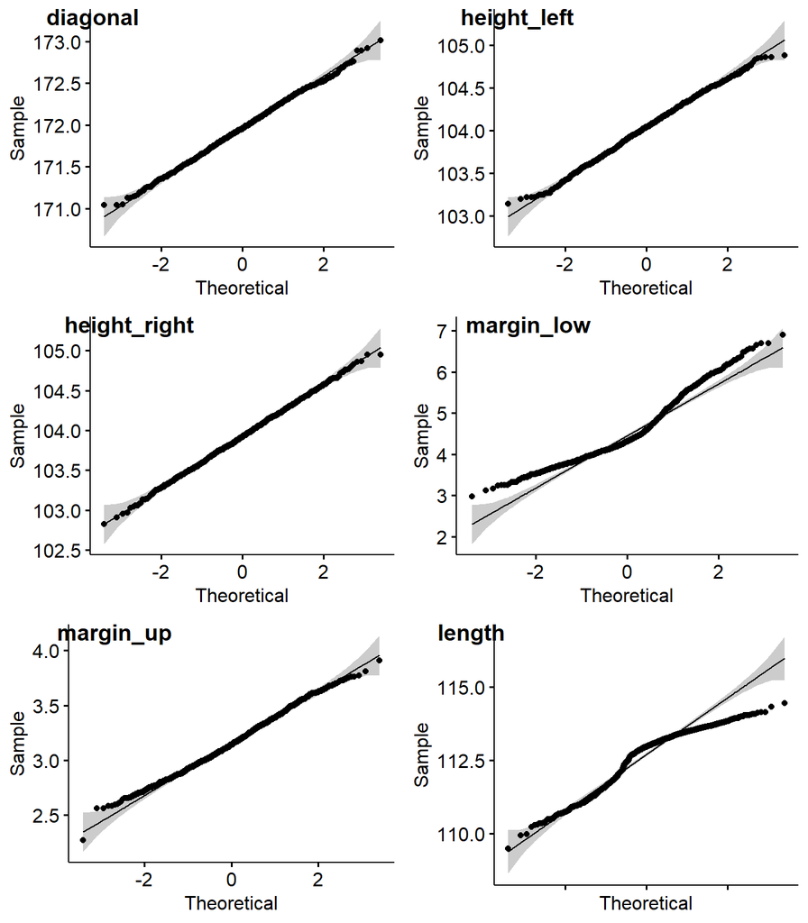

```r
# QQ plot
qq_diagonal     = ggqqplot(data =df3$diagonal)
qq_height_left  = ggqqplot(data =df3$height_left)
qq_height_right = ggqqplot(data =df3$height_right)
qq_margin_low   = ggqqplot(data =df3$margin_low)
qq_margin_up    = ggqqplot(data =df3$margin_up)
qq_length       = ggqqplot(data =df3$length)

ggarrange(qq_diagonal, qq_height_left, qq_height_right, qq_margin_low, qq_margin_up, qq_length + rremove("x.text"),
          labels = c("diagonal", "height_left", "height_right", "margin_low", "margin_up","length"),
          ncol = 2, nrow = 3)
```

- La distribution des variables semble etre normale, sauf pour $margin\_low$ et $length$

#### 3.2.1.2 Test de normalité de Shapiro-Wilk

Il existe plusieurs méthodes pour évaluer la normalité, notamment le test de normalité de **Kolmogorov-Smirnov (K-S)** ($n > = 5000$ ) et le test de **Shapiro-Wilk**.

- L’hypothèse nulle de ces tests est que “la distribution de l’échantillon est normale”. Si le test est significatif, la distribution est non-normale.
- La méthode de Shapiro-Wilk est largement recommandée pour les tests de normalité et fournit une meilleure puissance que K-S. Il est basé sur la corrélation entre les données et les scores normaux correspondants (Ghasemi and Zahediasl 2012).

```r
# Test de Shapiro
df3 %>% shapiro_test(diagonal, height_left, height_right, margin_low, margin_up, length)
```

```
## # A tibble: 6 x 3
##   variable     statistic        p
##   <chr>            <dbl>    <dbl>
## 1 diagonal         0.999 3.24e- 1
## 2 height_left      0.998 5.14e- 2
## 3 height_right     1.00  9.80e- 1
## 4 length           0.918 7.86e-28
## 5 margin_low       0.938 1.28e-24
## 6 margin_up        0.996 8.09e- 4
```

- La p-value > 0,05 indiquant que la distribution des données n’est pas significativement différente de la distribution normale. En d’autres termes, nous pouvons supposer la normalité.
- Le test de shapiro indique que la distribution des variables $length$, $margin\_low$ et $margin\_up$ n’est pas significativement normale.

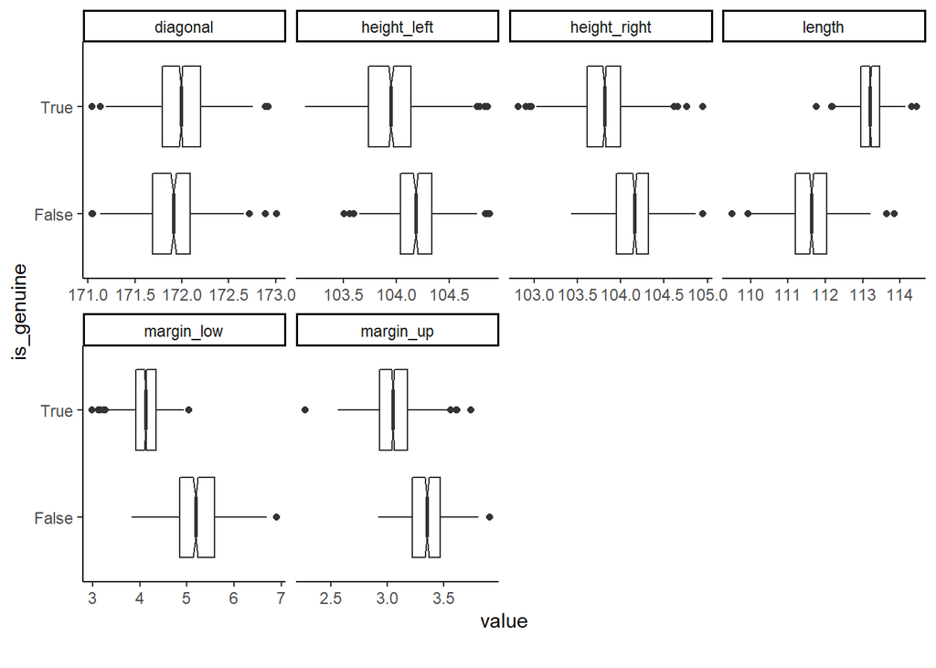

```r
# afficher les box plots
plot_boxplot(df3[,-1], "is_genuine", geom_boxplot_args = list(notch=TRUE), ggtheme = theme_classic())
```

Les box plots par catégorie de billet montrent que les médianes des deux groupes sont significativement différentes:

- valeurs plus fortes de la variable $length$ pour les vrais billets
- valeurs plus bas pour $margin\_low$ et $margin\_up$
- valeurs légèrement plus bas pour $height\_left$ et $height\_right$
- valeur légèrement plus fort pour $diagonal$

### 3.2.2 Test d’Homogénéité des Variances - hétéroscédasticité

Certains tests statistiques, comme le test T sur deux échantillons indépendants et le test ANOVA, supposent que les variances sont égales entre les groupes.

Il existe différents tests de variance qui peuvent être utilisés pour évaluer l’**égalité des variances**. Il s’agit notamment:

```
- Test F : Comparez les variances de deux groupes. Les données doivent être normalement distribuées.
- Test de Bartlett : Comparer les variances de deux groupes ou plus. Les données doivent être normalement distribuées.
- Le test de Levene : Une alternative robuste au test de Bartlett qui est moins sensible aux écarts de normalité.
- Test de Fligner-Killeen : un test non paramétrique qui est très robuste contre les écarts de normalité.
```

⚠️ *Il est à noter que le test de Levene est le plus couramment utilisé dans la littérature.* . [Source](https://www.datanovia.com/en/fr/lessons/test-dhomogeneite-des-variances-dans-r/)

Hypothèses statistiques :

- H0 : toutes les variances des echantillons sont égales
- H1 : au moins deux d’entre elles diffèrent.

Par conséquent, des valeurs $p$ inférieures à 0,05 suggèrent que les variances sont significativement différentes et que l’hypothèse d’homogénéité de la variance a été violée.

```r
# # Test de Levene avec de multiples variables indépendantes. La fonction leveneTest() [package car] peut être utilisée.
for (col in 3:ncol(df3)) {
  res = car::leveneTest(df3[,col] ~ as.factor(is_genuine), df3)
  print(colnames(df[col]))
  print(res)
  print("------------------------------------------------")
}
```

```
## [1] "diagonal"
## Levene's Test for Homogeneity of Variance (center = median)
##         Df F value Pr(>F)
## group    1  0.0109 0.9168
##       1498
## [1] "------------------------------------------------"
## [1] "height_left"
## Levene's Test for Homogeneity of Variance (center = median)
##         Df F value    Pr(>F)
## group    1  42.732 8.585e-11 ***
##       1498
## ---
## Signif. codes:  0 '***' 0.001 '**' 0.01 '*' 0.05 '.' 0.1 ' ' 1
## [1] "------------------------------------------------"
## [1] "height_right"
## Levene's Test for Homogeneity of Variance (center = median)
##         Df F value Pr(>F)
## group    1  1.9183 0.1663
##       1498
## [1] "------------------------------------------------"
## [1] "margin_low"
## Levene's Test for Homogeneity of Variance (center = median)
##         Df F value    Pr(>F)
## group    1  192.71 < 2.2e-16 ***
##       1498
## ---
## Signif. codes:  0 '***' 0.001 '**' 0.01 '*' 0.05 '.' 0.1 ' ' 1
## [1] "------------------------------------------------"
## [1] "margin_up"
## Levene's Test for Homogeneity of Variance (center = median)
##         Df F value Pr(>F)
## group    1  0.1817 0.6699
##       1498
## [1] "------------------------------------------------"
## [1] "length"
## Levene's Test for Homogeneity of Variance (center = median)
##         Df F value    Pr(>F)
## group    1  172.06 < 2.2e-16 ***
##       1498
## ---
## Signif. codes:  0 '***' 0.001 '**' 0.01 '*' 0.05 '.' 0.1 ' ' 1
## [1] "------------------------------------------------"
```

- L’hypothèse d’homogénéité de la variance a été violée pour les variables $height\_left$, $margin\_low$, et $length$.

### 3.2.3 Identifier les corrélations entre les variables du dataframe

[Source :](https://jkzorz.github.io/2019/06/11/Correlation-heatmaps.html)

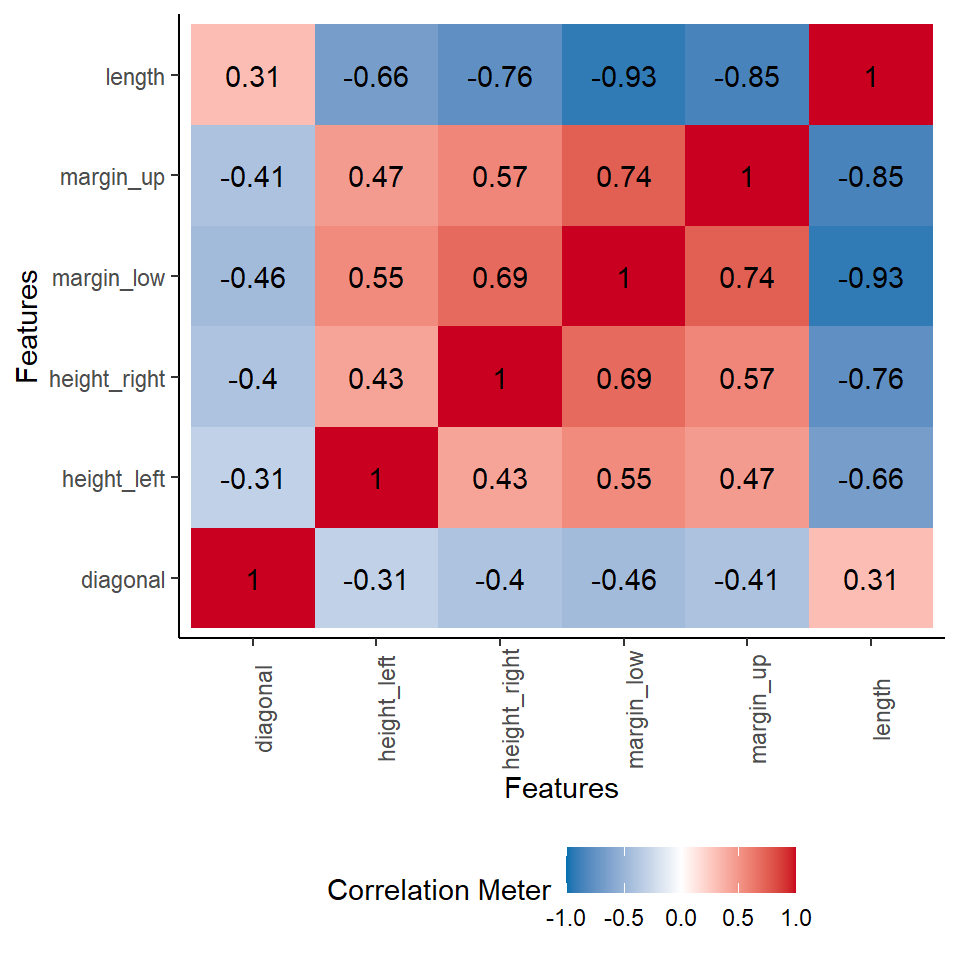

```r
# Crééer une matrice de crrélation
cc = cor(select_if(df3[,-1], is.numeric), method = "spearman")

# Heatmap
#corrplot(cc, tl.col = "black", addrect = 4, tl.cex = 0.7)
plot_correlation(cc, ggtheme = theme_classic())
```

- La variable $length$ est corrélée fortement avec les variables $margines$ (corrélation négative)
- $margin\_up$ et $margin\_low$ sont très corrélées positivement.

# 4 Modèle : Classification automatique avec kmeans

L’objectif est d’identifier des groupes homogènes, partageant des caractéristiques similaires (séparer les vrai et les faux billets en se basant sur les données géométriques).

```r
#df3 = df3[,-8]
# Centrage réduction des données : pour éviter que les variables à forte variance pèsent indûment sur les résultats
data.cr = scale(df3[,c(-1,-2)], center=T, scale=T)
data.cr = data.cr %>% as.data.frame()
#rownames(data.cr) = seq(1:nrow(df3))
#data.cr = tibble::rowid_to_column(as.data.frame(data.cr), "ID")
data.cr$is_genuine = df3$is_genuine
data.cr$ID = df3$ID
```

## 4.1 Nombre adéquat de groupes

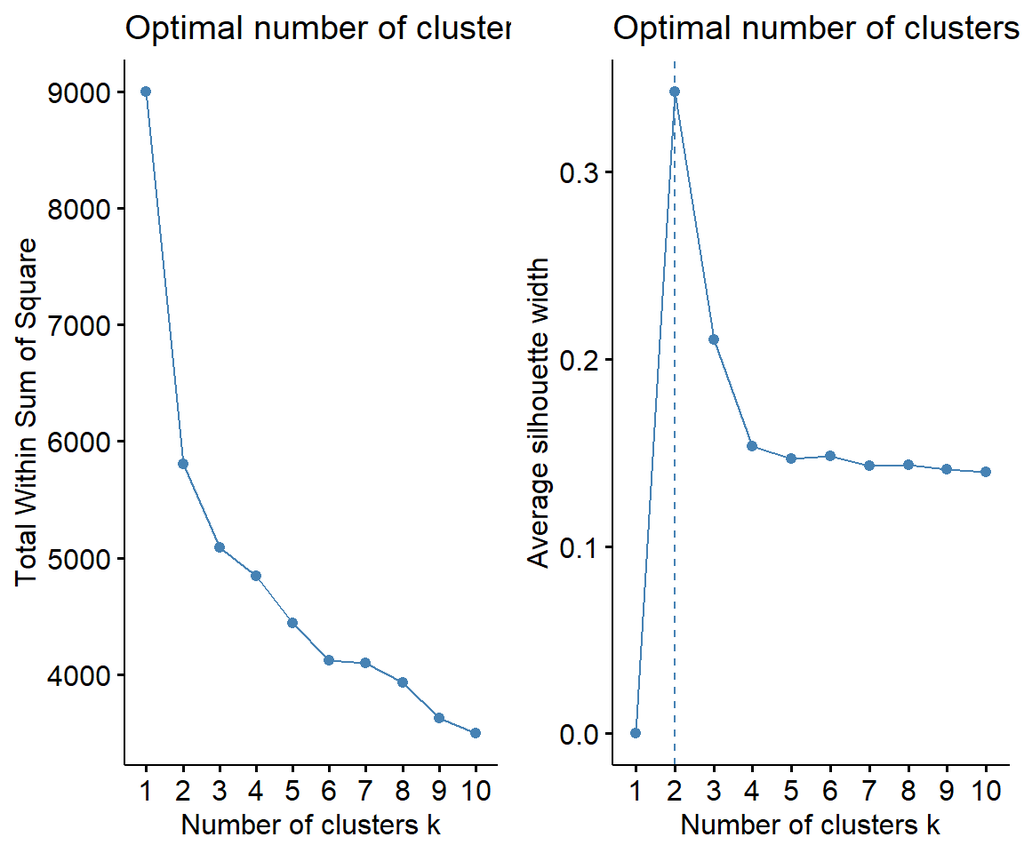

```r
# Identifier le nombre de centres optimals
grid.arrange(
fviz_nbclust(data.cr[c(-7,-8)], FUNcluster = kmeans, method = "wss"),
fviz_nbclust(data.cr[c(-7,-8)], FUNcluster = kmeans, method = "silhouette")
    ,nrow=1 )
```

- Le “coude” suggère que 2 groupes préservent l’information semblerait le nombre optimal

```r
# Kmeans avec les données centrées et réduites
#   center = 2 nombre de groupes demandés
#   nstart = 50 nombre d'essais avec différents individus de départ parce que les résultats sont dépendants de l’initialisation
# Set seed
set.seed(1234)
groupes.kmeans = kmeans(data.cr[c(-7,-8)], centers=2, nstart=50)
```

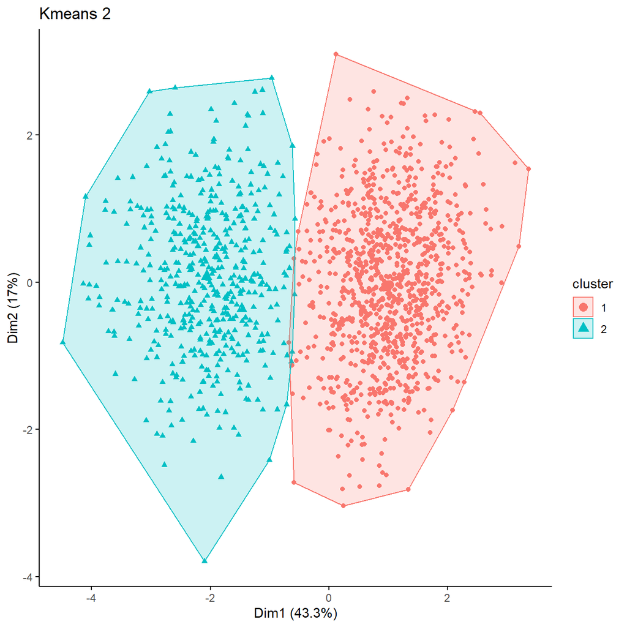

```r
# visualisation des clusters obtenus (projection sur le 1er plan factoriel) des deux méthodes
fviz_cluster(groupes.kmeans, data = data.cr[c(-7,-8)], main = "Kmeans 2", repel = TRUE, geom = c("point"), elipse.type = "euclid", ggtheme = theme_classic())
```

```r
#affichage des résultats - centroides
print(groupes.kmeans$centers)
```

```
##      diagonal height_left height_right margin_low  margin_up     length
## 1  0.09596839  -0.2818519   -0.3523018 -0.5522613 -0.4267813  0.5930423
## 2 -0.19425859   0.5705228    0.7131271  1.1178837  0.8638879 -1.2004325
```

- K-means clustering avec 2 clusters de taille 1004 et 496

```r
kmeans_basic_table <- data.frame(groupes.kmeans$size, groupes.kmeans$centers)
kmeans_basic_df <- data.frame(Cluster = groupes.kmeans$cluster, df3)
```

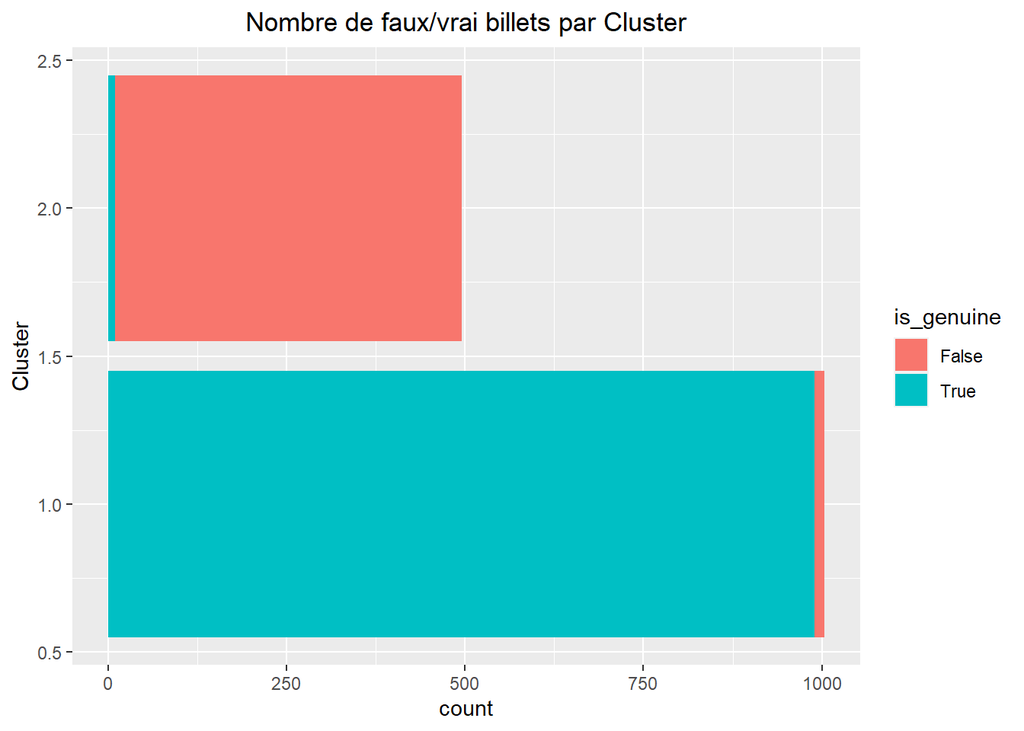

```r
# ggplot nombre de billets par cluster
ggplot(data = kmeans_basic_df, aes(y = Cluster)) +
  geom_bar(aes(fill = is_genuine)) +
  ggtitle("Nombre de faux/vrai billets par Cluster") +
  theme(plot.title = element_text(hjust = 0.5))
```

- Le premier cluster représente les vrai billets et le deuxième, les faux billets

```r
# Matrice de confusion
table(df3$is_genuine, kmeans_basic_df$Cluster)
```

```
##
##           1   2
##   False  14 486
##   True  990  10
```

- Le modèle kmeans avec 2 centres représente efficacement les deux types de billets dans notre jeu de données
- La précision (accuracy) du modèle : (990+486)/1500 = **98.4 %**

# 5 Modèle : Régression Logistique

- La régression logistique est utilisée pour prédire la classe (ou catégorie) d’individus en fonction d’une ou plusieurs variables prédictives (x). Elle est utilisée pour modéliser un résultat binaire, c’est-à-dire une variable qui ne peut avoir que deux valeurs possibles (ex. 0/1, oui/non, malade/non malade , **vrai**/**faux**).
- La régression logistique appartient à une famille, appelée modèle linéaire généralisé (GLM), développée pour étendre le modèle de régression linéaire à d’autres situations. D’autres synonymes sont la **régression logistique binaire**, la **régression logistique binomiale** et le **modèle logit** ([Source](http://www.sthda.com/english/articles/36-classification-methods-essentials/151-logistic-regression-essentials-in-r/)).
- La régression logistique ne renvoie pas directement la classe des observations. Elle nous permet d’estimer la **probabilité (p)** d’appartenance à une classe. La probabilité sera comprise entre **0** et **1**. Il faudra donc, décider de la probabilité seuil à partir de laquelle la catégorie bascule de l’une à l’autre. Par défaut, cette valeur est fixée à $p = 0,5$, mais en réalité, elle doit être fixée en fonction de l’objectif de l’analyse.

Dans cette partie, on va :

```
- Définir l'équation de régression logistique et les termes clés tels que log-odds et logit.
- effectuer une régression logistique dans R et interpréter les résultats
- faire des prédictions sur de nouvelles données de test et évaluer la précision du modèle.
```

## 5.1 Préparation des données

La régression logistique fonctionne pour des données qui contiennent des variables prédicteurs continues et/ou catégoriques.

L’exécution des étapes suivantes peut améliorer la précision de notre modèle :

```
- Supprimez les valeurs aberrantes potentielles
- Utiliser les variables prédicteurs normalement distribuées (ou faire la transformation logarithmique, racine ou box-cox, si ce n'est pas le cas).
- Supprimez les variables prédicteurs fortement corrélées pour minimiser l'overfitting (La présence de prédicteurs fortement corrélés peut conduire à une solution instable du modèle).
```

```r
# Inspecter les données
kable(df3[1:5,], caption = "Mon jeu de données")
```

Mon jeu de données

| ID | is_genuine | diagonal | height_left | height_right | margin_low | margin_up | length |
| --- | --- | --- | --- | --- | --- | --- | --- |
| 1 | True | 171.81 | 104.86 | 104.95 | 4.52 | 2.89 | 112.83 |
| 2 | True | 171.46 | 103.36 | 103.66 | 3.77 | 2.99 | 113.09 |
| 3 | True | 172.69 | 104.48 | 103.50 | 4.40 | 2.94 | 113.16 |
| 4 | True | 171.36 | 103.91 | 103.94 | 3.62 | 3.01 | 113.51 |
| 5 | True | 171.73 | 104.28 | 103.46 | 4.04 | 3.48 | 112.54 |

## 5.2 Calcul de la régression logistique

Commençant par utilier l’ensemble des variables.

- Pour des données binaires ou binomiales, la fonction lien est nommée le logit (ce que l’on indique à glm avec l’argument family=binomial(logit) :
  $$g(p) = log(p/1-p)$$
  .
- La fonction logit est le logarithme de la probabilité $(p1−p)$ ([source: qcbs, p54](http://r.qcbs.ca/workshop06/pres-fr/workshop06-pres-fr.html#54))

```r
# Modele logit
reg <- glm(as.factor(is_genuine) ~ diagonal + height_left + height_right + margin_low + margin_up + length,
           data = df3, family = binomial(link = "logit"))
# model <- glm( is_genuine ~., data = train.data, family = binomial) # toutes les vars inclues
summary(reg)
```

```
##
## Call:
## glm(formula = as.factor(is_genuine) ~ diagonal + height_left +
##     height_right + margin_low + margin_up + length, family = binomial(link = "logit"),
##     data = df3)
##
## Deviance Residuals:
##     Min       1Q   Median       3Q      Max
## -3.9591  -0.0011   0.0051   0.0281   2.6672
##
## Coefficients:
##               Estimate Std. Error z value Pr(>|z|)
## (Intercept)  -204.5582   241.7681  -0.846   0.3975
## diagonal        0.0680     1.0913   0.062   0.9503
## height_left    -1.7162     1.1038  -1.555   0.1200
## height_right   -2.2584     1.0720  -2.107   0.0351 *
## margin_low     -5.7756     0.9370  -6.164 7.11e-10 ***
## margin_up     -10.1531     2.1078  -4.817 1.46e-06 ***
## length          5.9129     0.8458   6.991 2.73e-12 ***
## ---
## Signif. codes:  0 '***' 0.001 '**' 0.01 '*' 0.05 '.' 0.1 ' ' 1
##
## (Dispersion parameter for binomial family taken to be 1)
##
##     Null deviance: 1909.543  on 1499  degrees of freedom
## Residual deviance:   84.685  on 1493  degrees of freedom
## AIC: 98.685
##
## Number of Fisher Scoring iterations: 10
```

- les prédicteurs significatifs sont : $height\_right$, $margin\_low$, $margin\_up$ et $length$

Notant que les fonctions coef() et summary() peuvent être utilisées pour extraire uniquement les coefficients, comme suit :

```r
summary(reg)$coef
```

```
##                   Estimate  Std. Error     z value     Pr(>|z|)
## (Intercept)  -204.55817914 241.7681477 -0.84609235 3.975012e-01
## diagonal        0.06800014   1.0912651  0.06231312 9.503135e-01
## height_left    -1.71622761   1.1037729 -1.55487389 1.199761e-01
## height_right   -2.25839238   1.0719591 -2.10678971 3.513581e-02
## margin_low     -5.77555573   0.9370329 -6.16366368 7.108083e-10
## margin_up     -10.15305151   2.1078273 -4.81683280 1.458548e-06
## length          5.91290062   0.8457752  6.99110205 2.727353e-12
```

- Dans le cadre d’un modèle logistique, généralement on ne présente pas les coefficients du modèle mais **leur valeur exponentielle**, cette dernière correspondant en effet à des **odds ratio**, également appelés **rapports des cotes**.
- L’odds ratio diffère du risque relatif. Cependent son interprétation est similaire.
- Un odds ratio de **1** signifie l’**absence d’effet**. Un odds ratio largement **supérieur à 1** correspond à une **augmentation du phénomène étudié** et un odds ratio largement **inféieur à 1** correspond à une **diminution du phénomène étudié**([source](https://larmarange.github.io/analyse-R/regression-logistique.html#pr%C3%A9paration-des-donn%C3%A9es)).

## 5.3 Interpretation

On constate que seuls 4 des 6 prédicteurs sont associés de manière significative au résultat.

D’après les résultats de la régression logistique, on peut remarquer que certaines variables ne sont pas statistiquement significatives. Leur maintien dans le modèle peut contribuer à un ajustement excessif (**overfiting**). Elles doivent donc être éliminées. Ceci peut être fait automatiquement en utilisant des techniques statistiques, y compris les méthodes de régression pas à pas (**stepwise regression**) et de régression pénalisée (**penalized regression**). En bref, elles consistent à sélectionner un modèle optimal avec un ensemble réduit de variables, sans compromettre la précision du modèle.

## 5.4 Représentation graphique du modèle

Il est possible de représenter graphiquement les différents odds ratios avec la fonction ggcoef_model de GGally.

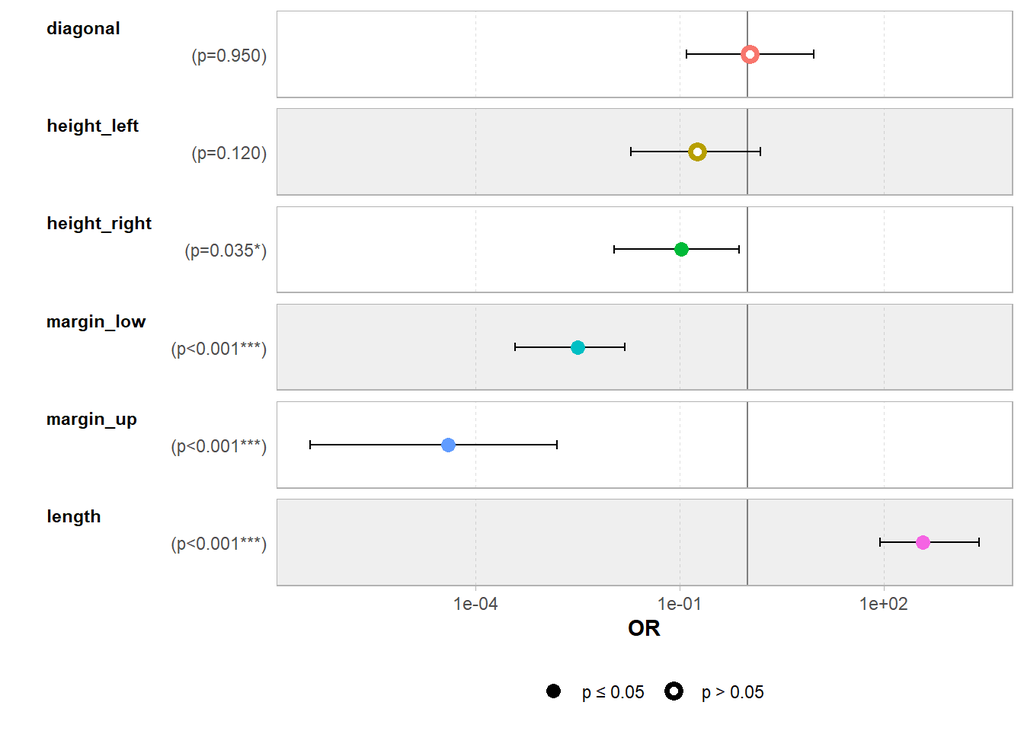

```r
library(GGally)
ggcoef_model(reg, exponentiate = TRUE)
```

## 5.5 Représentation graphique des effets

L’extension effects propose une représentation graphique résumant les effets de chaque variable du modèle.

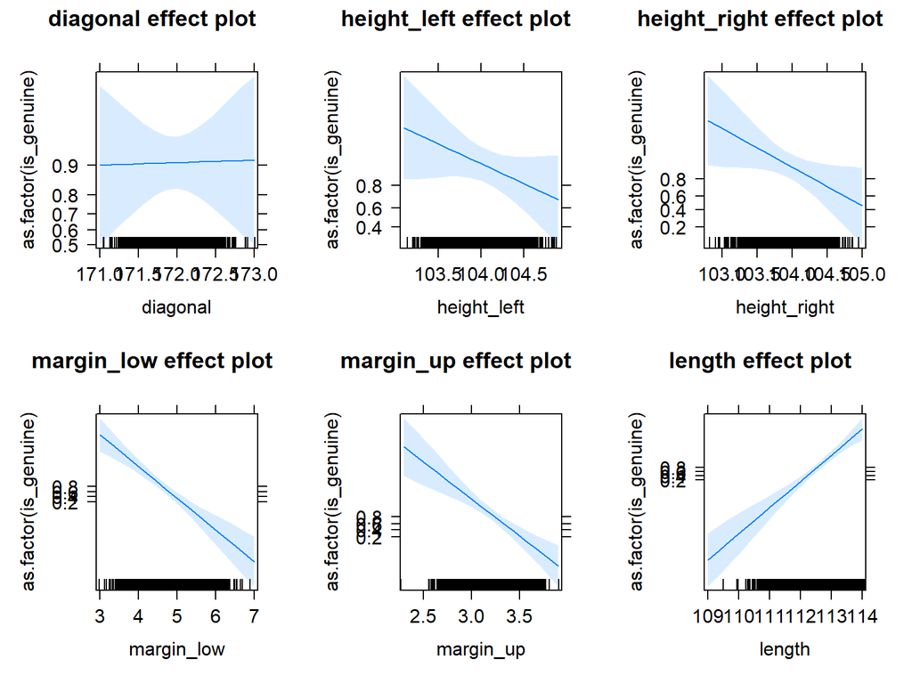

```r
library(effects)
plot(allEffects(reg))
```

## 5.6 Matrice de confusion

Une manière de tester la qualité d’un modèle est le calcul d’une matrice de confusion, c’est-à-dire le tableau croisé des valeurs observées et celles des valeurs prédites en appliquant le modèle aux données d’origine.

La méthode predict avec l’argument type=“response” permet d’appliquer notre modèle logistique à un tableau de données et renvoie pour chaque individu la probabilité qu’il ait vécu le phénomène étudié (un vrai billet).

```r
billet.pred <- predict(reg, type = "response", newdata = df3)
head(billet.pred, n = 10)
```

```
##         1         2         3         4         5         6         7         8
## 0.8638641 0.9999948 0.9996548 0.9999989 0.7807366 0.9963499 0.7881230 0.9999545
##         9        10
## 0.9971656 0.9997061
```

Or notre variable étudiée est de type binaire. Nous devons donc transformer nos probabilités prédites en une variable du type « vrai / faux ». Usuellement, les probabilités prédites seront réunies en deux groupes selon qu’elles soient supérieures ou inférieures à la moitié. La matrice de confusion est alors égale à :

```r
table(billet.pred > 0.5, df3$is_genuine)
```

```
##
##         False True
##   FALSE   491    4
##   TRUE      9  996
```

```r
accuracy<- (491+996)/ (491+4+9+996)
print(accuracy)
```

```
## [1] 0.9913333
```

⚠️ * Nous avons donc 13 (4+9) prédictions incorrectes sur un total de 1500, soit un taux de mauvais classement de 0.87 %. ⚠️ * La précision (accuracy) du modèle est de 99.13%

## 5.7 Identifier les variables ayant un effet significatif

Les $p-values$ associées aux odds ratios nous indique si un odd ratio est significativement différent de 1, par rapport à la modalité de référence. Mais cela n’indique pas si globalement une variable a un effet significatif sur le modèle. Pour tester l’effet global sur un modèle, on peut avoir recours à la fonction drop1. Cette dernière va tour à tour supprimer chaque variable du modèle et réaliser une analyse de variance (ANOVA) pour voir si la variance change significativement ou d’appliquer une ANOVA diréctement.

```r
#drop1(reg, test = "Chisq")
Anova(reg)
```

```
## Analysis of Deviance Table (Type II tests)
##
## Response: as.factor(is_genuine)
##              LR Chisq Df Pr(>Chisq)
## diagonal        0.004  1    0.95030
## height_left     2.483  1    0.11510
## height_right    5.114  1    0.02373 *
## margin_low    121.101  1  < 2.2e-16 ***
## margin_up      42.656  1  6.525e-11 ***
## length        224.038  1  < 2.2e-16 ***
## ---
## Signif. codes:  0 '***' 0.001 '**' 0.01 '*' 0.05 '.' 0.1 ' ' 1
```

La suppression des variables $diagonal$ et $height\_left$ ne modifient significativement pas le modèle, indiquant l’absence d’effet de ces variables.

## 5.8 Sélection de modèles

Il est toujours tentant lorsque l’on recherche les facteurs associés à un phénomène d’inclure un nombre important de variables explicatives potentielles dans un modèle logistique. Cependant, un tel modèle n’est pas forcément le plus efficace et certaines variables n’auront probablement pas d’effet significatif sur la variable d’intérêt.

La technique de sélection descendante pas à pas est une approche visant à améliorer son modèle explicatif. On réalise un premier modèle avec toutes les variables spécifiées, puis on regarde s’il est possible d’améliorer le modèle en supprimant une des variables du modèle. Si plusieurs variables permettent d’améliorer le modèle, on supprimera la variable dont la suppression améliorera le plus le modèle. Puis on recommence le même procédé pour voir si la suppression d’une seconde variable peut encore améliorer le modèle et ainsi de suite. Lorsque le modèle ne peut plus être améliorer par la suppresion d’une variable, on s’arrête.

Il faut également définir un critère pour déterminer la qualité d’un modèle. L’un des plus utilisés est le *Akaike Information Criterion* ou *AIC*. **Plus l’AIC sera faible, meilleure sera le modèle**.

La fonction **step** permet justement de sélectionner le **meilleur modèle par une procédure pas à pas descendante basée sur la minimisation de l’AIC**. La fonction affiche les différentes étapes de la sélection et renvoie le modèle final.

```r
reg2 <- step(reg)
```

```
## Start:  AIC=98.68
## as.factor(is_genuine) ~ diagonal + height_left + height_right +
##     margin_low + margin_up + length
##
##                Df Deviance    AIC
## - diagonal      1   84.689  96.69
## <none>              84.685  98.68
## - height_left   1   87.168  99.17
## - height_right  1   89.799 101.80
## - margin_up     1  127.341 139.34
## - margin_low    1  205.785 217.79
## - length        1  308.723 320.72
##
## Step:  AIC=96.69
## as.factor(is_genuine) ~ height_left + height_right + margin_low +
##     margin_up + length
##
##                Df Deviance    AIC
## <none>              84.689  96.69
## - height_left   1   87.173  97.17
## - height_right  1   89.925  99.92
## - margin_up     1  128.287 138.29
## - margin_low    1  211.175 221.17
## - length        1  309.492 319.49
```

- Le modèle initial a un AIC de 98.68. À la première étape, il apparait que la suppression de la variable *diagonal* permet de diminuer l’AIC à 96.69. Lors de la seconde étape, toute suppression d’une autre variable ferait augmenter l’AIC. La procédure s’arrête donc.

Pour obtenir directement l’AIC d’un modèle donné, on peut utiliser la fonction AIC.

```r
AIC(reg)
```

```
## [1] 98.68477
```

```r
AIC(reg2)
```

```
## [1] 96.68865
```

Effectuer une analyse de variance ou ANOVA pour comparer les deux modèles :

```r
anova(reg, reg2, test = "Chisq")
```

```
## Analysis of Deviance Table
##
## Model 1: as.factor(is_genuine) ~ diagonal + height_left + height_right +
##     margin_low + margin_up + length
## Model 2: as.factor(is_genuine) ~ height_left + height_right + margin_low +
##     margin_up + length
##   Resid. Df Resid. Dev Df   Deviance Pr(>Chi)
## 1      1493     84.685
## 2      1494     84.689 -1 -0.0038843   0.9503
```

- Il n’y a pas de différences significatives entre nos deux modèles (notre second modèle explique tout autant de variance que notre premier modèle, tout en étant plus parcimonieux).

## 5.9 Mise à jour du modèle

On supprime les variables non significatifs ($height\_left$ et $diagonal$) du modèle et on recalcul les coefficients.

```r
reg3 <- update(reg, ~. - height_left - diagonal)
summary(reg3)
```

```
##
## Call:
## glm(formula = as.factor(is_genuine) ~ height_right + margin_low +
##     margin_up + length, family = binomial(link = "logit"), data = df3)
##
## Deviance Residuals:
##    Min      1Q  Median      3Q     Max
## -4.011  -0.001   0.005   0.029   2.657
##
## Coefficients:
##               Estimate Std. Error z value Pr(>|z|)
## (Intercept)  -323.4452   139.5319  -2.318   0.0204 *
## height_right   -2.7839     1.0779  -2.583   0.0098 **
## margin_low     -6.0195     0.8968  -6.712 1.92e-11 ***
## margin_up     -10.2075     2.0788  -4.910 9.10e-07 ***
## length          5.9831     0.8267   7.237 4.58e-13 ***
## ---
## Signif. codes:  0 '***' 0.001 '**' 0.01 '*' 0.05 '.' 0.1 ' ' 1
##
## (Dispersion parameter for binomial family taken to be 1)
##
##     Null deviance: 1909.543  on 1499  degrees of freedom
## Residual deviance:   87.173  on 1495  degrees of freedom
## AIC: 97.173
##
## Number of Fisher Scoring iterations: 10
```

```r
# Performance du modèle mis à jour
billet.pred <- predict(reg3, type = "response", newdata = df3)
table(billet.pred > 0.5, df3$is_genuine)
```

```
##
##         False True
##   FALSE   492    3
##   TRUE      8  997
```

```r
accuracy<- (492+997)/ (492+3+8+997)
print(accuracy)
```

```
## [1] 0.9926667
```

🔴 On observe une legère amélioration du modèle (99.26% au lieu de 99.13%).

## 5.10 Tester le modèle sur des données divisées (training/test)

```r
# Split le dataframe en train/test
set.seed(5)
split = sample.split(df3$is_genuine)
train.data = subset(df3, split==TRUE)
test.data = subset(df3, split==FALSE)
```

### 5.10.1 Performances des modèles

#### 5.10.1.1 Modèle logit

```r
# Entrainer le modèle logit sur le jeu de données train
reg4_logit = glm(as.factor(is_genuine) ~ height_right + margin_low + margin_up + length,
           data = train.data, family = binomial(link = "logit"))

# Performance du modèle sur le jeu test
reg4_pred_logit_test = predict(reg4_logit, type = "response", newdata = test.data)

#caret::confusionMatrix(table(reg4_pred_test > 0.5, test.data$is_genuine))
table(reg4_pred_logit_test > 0.5, test.data$is_genuine)
```

```
##
##         False True
##   FALSE   162    0
##   TRUE      5  333
```

🔴 * Nous avons seulement 5 prédictions incorrectes sur un total de 500, soit un taux de mauvais classement de 1 %.

🔴 * L’accuracy du modèle est de 99 %

#### 5.10.1.2 Modèle step

```r
# Entrainer le modèle "step" sur le jeu de données train
reg4_step = step(reg4_logit)
```

```
## Start:  AIC=75.57
## as.factor(is_genuine) ~ height_right + margin_low + margin_up +
##     length
##
##                Df Deviance     AIC
## <none>              65.572  75.572
## - height_right  1   68.316  76.316
## - margin_up     1   94.891 102.891
## - margin_low    1  154.157 162.157
## - length        1  242.693 250.693
```

```r
# Performance du modèle "step" sur le jeu de données test
reg4_pred_step_test <- predict(reg4_step, type = "response", newdata = test.data)
table(reg4_pred_step_test >0.5, test.data$is_genuine)
```

```
##
##         False True
##   FALSE   162    0
##   TRUE      5  333
```

🔴 Les deux modèles ont la même performance (accuracy de 99%)

#### 5.10.1.3 Courbe ROC

Receiver Operating Characteristic Curve (ROCR). On peut en générer grâce au package ROCR ([source](http://www.duclert.org/r-apprentissage/courbes-ROC-R.php)).

Spécificité et sensibilité :

```
- la sensibilité est : TP / (TP + FN) = TP / P.
- la spécificité est : TN / (TN + FP) = TN / N.
```

avec

```
* TP (true positives) : les prédits positifs qui le sont vraiment.
* FP (false positives) : les prédits positifs qui sont en fait négatifs.
* TN (true negatives) : les prédits négatifs qui le sont vraiment.
* FN (false negatives) : les prédits négatifs qui sont en fait positifs.
* P (positives) : tous les positifs quelque soit l'état de leur prédiction. P = TP + FN.
* N (negatives) : tous les négatifs quelque soit l'état de leur prédiction. N = TN + FP.
```

```r
# ROCR ored_logit
library(ROCR)
rocr_pred = prediction(reg4_pred_logit_test, test.data$is_genuine)
perf_ROCR = performance(rocr_pred, "auc")
perf_ROCR@y.values
```

```
## [[1]]
## [1] 0.9996943
```

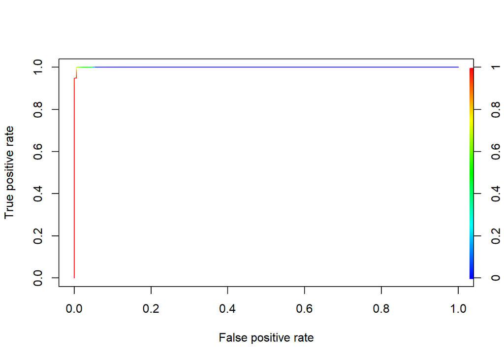

```r
# Visualisation graphique
perf_ROCR = performance(rocr_pred, "tpr", "fpr")
plot(perf_ROCR, colorize=TRUE)
```

## 5.11 Cross validation

Le package carret (Classification And REgression Training) intègre plusieurs fonctions pour faire du machine learnin (comme sklearn dans Python).

Même si “caret” propose des techniques de rééchantillonnage pour l’évaluation des modèles, nous allons subdiviser les données en échantillons d’apprentissage (70%) et de test (30%). Nous utilisons la commande createDataPartition() de la librairie “caret” (source).

```r
# Recoder la variable réponse en factor dans le df3
df3 <- df3 %>%
  mutate(is_genuine = factor(is_genuine))
```

### 5.11.1 Echantillonage

Nous effectuons un échantillonnage stratifié sur la variable cible (is_genuine). Les proportions des classes devraient être respectées dans les sous-échantillons.

```r
# Echantillonnage aléatoire en équilibrant les proportions de billets
set.seed(100)
trainIndex <- createDataPartition(df3$is_genuine, p=0.7, list=F)
print(length(trainIndex))
```

```
## [1] 1050
```

```r
#data frame pour les individus en apprentissage
train = df3[trainIndex,]
print(dim(train))
```

```
## [1] 1050    8
```

Et pour l’échantillon test, nous passons par l’indiçage négatif qui indique les individus à exclure.

```r
#data frame pour les individus en test
test <- df3[-trainIndex,]
print(dim(test))
```

```
## [1] 450   8
```

Nous vérifions la distribution des classes.

```r
#fréquences relatives des classes dans l'éch. d'apprentissage
print(prop.table(table(train$is_genuine)))
```

```
##
##     False      True
## 0.3333333 0.6666667
```

```r
#distribution des classes dans l'éch. test
print(prop.table(table(test$is_genuine)))
```

```
##
##     False      True
## 0.3333333 0.6666667
```

### 5.11.2 Modèle de regression retenu

```r
#paramètre du processus d'apprentissage - cross validation
fitControl = trainControl(method = "cv", number = 10)

#apprentissage - régression logistique
m_lr <- train(is_genuine ~ height_right + margin_low + margin_up + length,
              data = train, method="glm", trControl=fitControl, family = "binomial")

kable(m_lr$results, caption = "Description")
```

Description

| parameter | Accuracy | Kappa | AccuracySD | KappaSD |
| --- | --- | --- | --- | --- |
| none | 0.9904762 | 0.9784774 | 0.0077762 | 0.017667 |

Le modèle sous-jacent est accessible via la propriété $finalModel

```r
print(m_lr$finalModel)
```

```
##
## Call:  NULL
##
## Coefficients:
##  (Intercept)  height_right    margin_low     margin_up        length
##     -464.771        -1.861        -6.484       -10.329         6.408
##
## Degrees of Freedom: 1049 Total (i.e. Null);  1045 Residual
## Null Deviance:       1337
## Residual Deviance: 59.83     AIC: 69.83
```

- l’AIC est beaucoup plus faible par rapport aux enciens modèles (~ 96)

### 5.11.3 Prédiction sur l’échantillon test

Pour évaluer la qualité de notre modèle, nous l’appliquons sur l’échantillon test

```r
#prediction
pred = predict(m_lr, newdata=test)

#distribution des classes prédites
print(table(pred))
```

```
## pred
## False  True
##   148   302
```

🔴 Il y a 302 prédictions positives c.-à-d. 302 billets de l’échantillon test sont désignées vrai billets !

### 5.11.4 Matrice de confusion et indicateurs d’évaluation

La matrice de confusion matérialise la confrontation entre les classes observées et prédites. Des indicateurs (métriques) interprétables en sont déduits [source](http://topepo.github.io/caret/measuring-performance.html#measures-for-predicted-classes).

Nous utilisons la commande confusionMatrix(). Un troisième paramètre permet de désigner la modalité cible, nécessaire pour le calcul de certains indicateurs. Dans notre cas, nous cherchons avant tout à identifier les vrai billets (is_genuine = True).

```r
#matrice de confusion
mat = confusionMatrix(data=pred, reference=test$is_genuine, positive="True")
print(mat)
```

```
## Confusion Matrix and Statistics
##
##           Reference
## Prediction False True
##      False   148    0
##      True      2  300
##
##                Accuracy : 0.9956
##                  95% CI : (0.984, 0.9995)
##     No Information Rate : 0.6667
##     P-Value [Acc > NIR] : <2e-16
##
##                   Kappa : 0.99
##
##  Mcnemar's Test P-Value : 0.4795
##
##             Sensitivity : 1.0000
##             Specificity : 0.9867
##          Pos Pred Value : 0.9934
##          Neg Pred Value : 1.0000
##              Prevalence : 0.6667
##          Detection Rate : 0.6667
##    Detection Prevalence : 0.6711
##       Balanced Accuracy : 0.9933
##
##        'Positive' Class : True
##
```

- Le taux de succès (accuracy, à ne pas confondre avec la précision) est 99.56%.
- L’intervalle de confiance à 95% est fournie. En effet, l’ensemble de test n’est qu’un échantillon représentatif (au mieux) de la population. Les taux mesurés sont assortis d’une certaine incertitude. Nous disposons d’autres indicateurs, en particulier la **sensibilité** qui, associée à la classe positive “is_genuine = True”, est égale à 300/(300+0) = 100 %

### 5.11.5 Autre méthode d’évaluation du modèle

#### 5.11.5.1 Courbe LIFT (courbe de gain)

La courbe LIFT ou courbe de gain est utilisée pour mesurer l’efficacité d’un ciblage ([scoring](http://topepo.github.io/caret/measuring-performance.html#lift-curves)). Nous travaillons toujours sur l’échantillon test. Pour la construire, en sus des classes observées, nous avons besoin de la probabilité (score) d’être de la classe positive fournie par le modèle [P(is_genuine = True / description)].

```r
#score des individus positifs (vrai billets)
score = predict(m_lr, test, type="prob")[,"True"]
```

Avec l’option “type = prob”, predict() produit pour chaque individu les probabilités d’appartenance aux classes.

Nous créons un data frame regroupant les classes observées et les scores.

```r
# tableau de données pour le scoring
liftdata <- data.frame(classe=test$is_genuine)
liftdata$score <- score
```

Nous faisons appel à la fonction lift() de caret en spécifiant la modalité cible pour le scoring, à savoir “class = True”.

```r
#objet lift
lift_obj = lift(classe ~ score, data=liftdata, class="True")
print(lift_obj)
```

```
##
## Call:
## lift.formula(x = classe ~ score, data = liftdata, class = "True")
##
## Models: score
## Event: True (66.7%)
```

- La fonction print() indique seulement la proportion des observations positives (is_genuine = True).

Pour obtenir la courbe proprement dite, nous appelons la fonction plot() associée à l’objet.

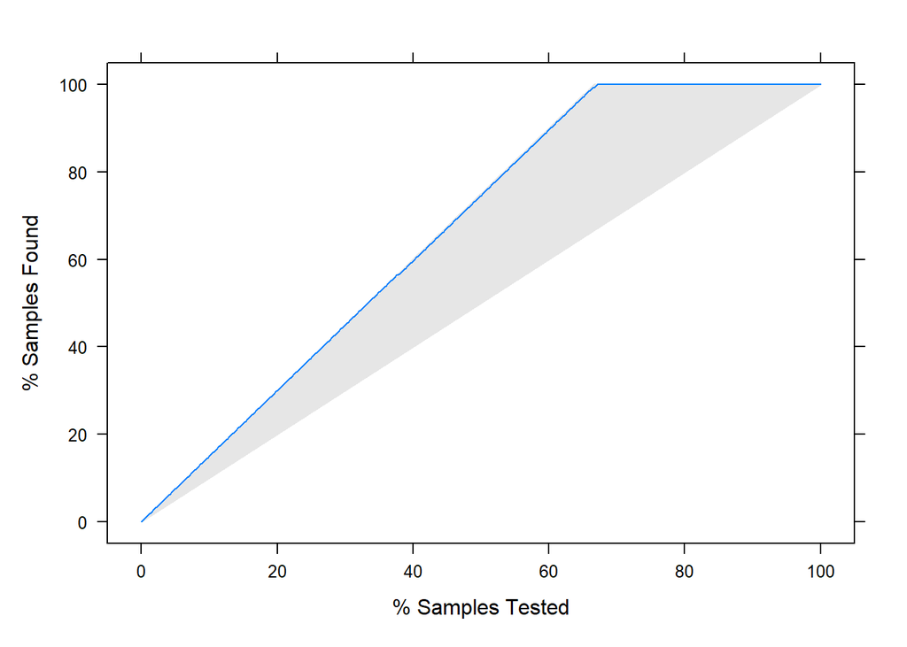

```r
#affichage de la courbe lift
plot(lift_obj)
```

- La courbe est proche de la limite théorique (atteinte lorsque tous les billets = True se voient attribuer un score plus élevé que les billets = False). Notre ciblage est d’excellente qualité.

#### 5.11.5.2 La Courbe ROC

La courbe ROC vise à mesurer la qualité d’un modèle en s’affranchissant des coûts de mauvaise affectation et de la représentativité de l’échantillon utilisé (les proportions des classes dans l’échantillon peut être différent de celui de la population).

```r
#library
library(pROC)
#objet roc
roc_obj = roc(test$is_genuine =="True",score)
```

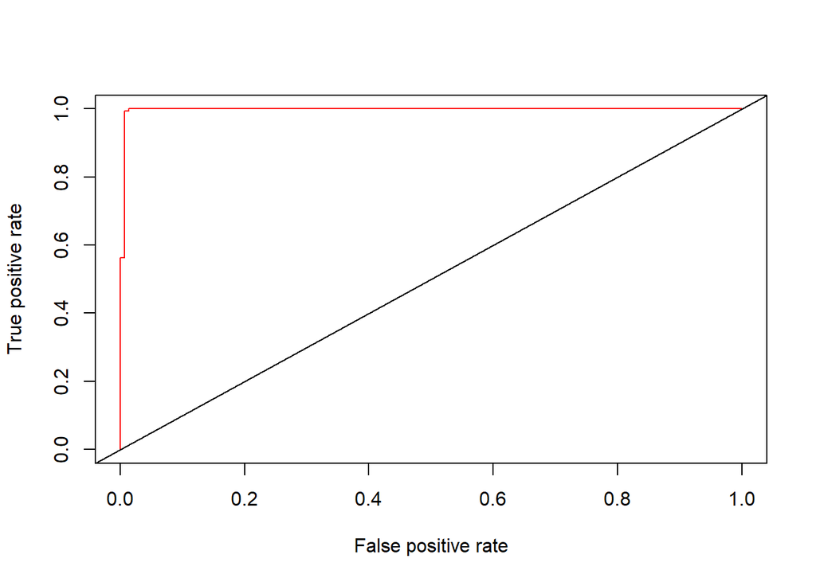

```r
#plot de l'objet roc
plot(1-roc_obj$specificities, roc_obj$sensitivities, type="l", col = "red", xlab ="False positive rate", ylab = "True positive rate" )
abline(0,1)
```

## 5.12 Tester le modèle final sur un nouveau jeu de données

```r
# importer le jeu de données
new_df = read.csv("data/billets_production.csv", sep = ',')
#new_df = read.csv("data/test2.csv", sep = ';')
#new_df = read.csv("data/billets_essai.csv", sep = ',')

# prediction
pred_new = predict(m_lr, newdata=new_df)

#distribution des classes prédites
print(table(pred_new))
```

```
## pred_new
## False  True
##     3     2
```

```r
#score des individus positifs (vrai billets)
score2 = predict(m_lr, new_df, type="prob")[,"True"]

# tableau de données pour le scoring
liftdata_new <- data.frame(classe=new_df$id)
liftdata_new$score <- score2

# Ajouter les prédictions au fichier original
df4 = new_df %>% mutate(prediction = pred_new, Proba_vrai = score2)
kable(df4, caption = "Mes résultats")
```

Mes résultats

| diagonal | height_left | height_right | margin_low | margin_up | length | id | prediction | Proba_vrai |
| --- | --- | --- | --- | --- | --- | --- | --- | --- |
| 171.76 | 104.01 | 103.54 | 5.21 | 3.30 | 111.42 | A_1 | False | 0.0000125 |
| 171.87 | 104.17 | 104.13 | 6.00 | 3.31 | 112.09 | A_2 | False | 0.0000016 |
| 172.00 | 104.58 | 104.29 | 4.99 | 3.39 | 111.57 | A_3 | False | 0.0000133 |
| 172.49 | 104.55 | 104.34 | 4.44 | 3.03 | 113.20 | A_4 | True | 0.9983518 |
| 171.65 | 103.63 | 103.56 | 3.77 | 3.16 | 113.33 | A_5 | True | 0.9999916 |

- Les billets A_1, A_2 et A_3 sont des faux billets (score faible) et es 2 autres sont des vrai billets avec une forte probabilité

# 6 Implémenter le modèle de régression logistique avec shiny

Construire un outil qui prend comme entrée un fichier CSV des données que vous voulez obtenir des prédictions et la sortie sera les valeurs prédites ([tuto](https://www.r-bloggers.com/2021/01/how-to-share-your-machine-learning-models-with-shiny/)).

```r
# Enregistrer notre modèle final
saveRDS(m_lr, "regressionModel.rds")
```

# 7 Références

[Atelier sur les modèles linéaires](http://r.qcbs.ca/workshop06/pres-fr/workshop06-pres-fr.html#121)

[Régression linéaire multiple, sthda](http://www.sthda.com/english/articles/40-regression-analysis/168-multiple-linear-regression-in-r/)

[Multicolinéarité des variables, sthda](http://www.sthda.com/english/articles/39-regression-model-diagnostics/160-multicollinearity-essentials-and-vif-in-r/)

[Max Kuhn, “The caret Package”](http://topepo.github.io/caret/index.html)